# Моментум-стратегии и reality check (ТЗ 29.07.2015)

> Количество исследумых компаний – **55**

#### **Таблица 1. Исследуемые компании**

|  | Col1 | CUR_MKT_CAP | name | industry_sector | industry_group | CRNCY_ADJ_MKT_CAP | eqy_free_float_pct | pe_ratio | current_ev_to_t12m_ebitda |
| --- | --- | --- | --- | --- | --- | --- | --- | --- | --- |
| 1 | ABEV3 BS Equity |  | AMBEV SA | Consumer, Non-cyclical |  | 79943.64 | 28.18 | 22.7731505011885 | 14,26 |
| 2 | BBAS3 BS Equity | 50717881254 | BANCO DO BRASIL S.A. | Financial |  | 14019.76 | 36.47 | 3.39830448109867 |  |
| 3 | BBDC3 BS Equity |  | BANCO BRADESCO S.A. | Financial |  | 33236.26 | 26.02 | 7.49060250567444 |  |
| 4 | BBDC4 BS Equity |  | BANCO BRADESCO SA-PREF | Financial |  | 33236.26 | 97.31 | 6.96553205406779 |  |
| 5 | BRAP4 BS Equity | 2673680298.98 | BRADESPAR SA -PREF | Financial |  | 739.08 | 98.06 |  |  |
| 6 | BRFS3 BS Equity | 58263763367.88 | BRF SA | Consumer, Non-cyclical |  | 16105.64 | 86.05 | 24.2414376497991 | 12,32 |
| 7 | BRKM5 BS Equity | 8380231363.98 | BRASKEM SA-PREF A | Basic Materials |  | 2316.52 | 42.26 | 5.90684259557888 | 3,72 |
| 8 | BRML3 BS Equity | 5379070347.6 | BR MALLS PARTICIPACOES SA | Financial |  | 1486.92 | 89.75 | 16.0221217000978 | 5,90 |
| 9 | BRPR3 BS Equity | 3131398557 | BR PROPERTIES SA | Financial |  | 865.6 | 44.71 | 35.9180652399437 | 9,15 |
| 10 | BVMF3 BS Equity | 18730800000 | BM&amp;FBOVESPA SA | Financial |  | 5177.69 | 87.62 | 17.3787687863985 | 11,76 |

[output cut: 45 more lines]

> Период отслеживания менялся от **1** до **12** месяцев

> Период ожидания менялся от **0** до **8** недель

> Период инвестирования менялся от **1** до **12** месяцев

## 1. Моментум стратегии при равных весах. Ранжирование по средней доходности (бенчмарк 6% годовых - только для reality check)

> Всего было рассмотрено **5184** стратегий

#### **Таблица 2. Все стратегии**

|  | mean | t | p-value | hist_per | moment_per | invest_per | percent | Amount_of_negative |
| --- | --- | --- | --- | --- | --- | --- | --- | --- |
| 1 | -0.000974 | 0.431814 | 0.666945 | 4 | 0 | 4 | 0.5 | 47 |
| 2 | -0.001811 | 1.083955 | 0.28138 | 4 | 0 | 8 | 0.5 | 43 |
| 3 | -0.00043 | 0.277373 | 0.782152 | 4 | 0 | 12 | 0.5 | 48 |
| 4 | -0.001292 | 0.871713 | 0.385764 | 4 | 0 | 16 | 0.5 | 51 |
| 5 | -0.001137 | 0.892299 | 0.374694 | 4 | 0 | 20 | 0.5 | 50 |
| 6 | -0.001191 | 1.137371 | 0.258506 | 4 | 0 | 24 | 0.5 | 56 |
| 7 | -0.001388 | 1.572287 | 0.119514 | 4 | 0 | 28 | 0.5 | 57 |
| 8 | -0.001378 | 1.668516 | 0.098809 | 4 | 0 | 32 | 0.5 | 52 |
| 9 | -0.000964 | 1.142323 | 0.256454 | 4 | 0 | 36 | 0.5 | 49 |
| 10 | -0.000562 | 0.71568 | 0.476105 | 4 | 0 | 40 | 0.5 | 50 |

[output cut: 5174 more lines]

#### **Рисунок 1.**

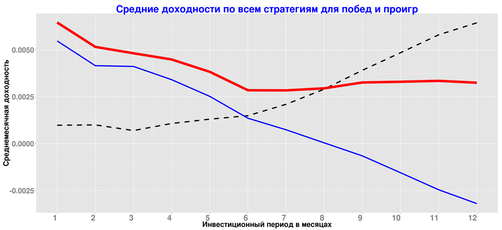

#### **Таблица 3. Агрегированные по всем стратегиям доходности победителей и проигравших**

|  | invest.per | aggr.winner | aggr.loser | delta |
| --- | --- | --- | --- | --- |
| 1 | 1 | 0.0065 | 0.0055 | 0.001 |
| 2 | 2 | 0.0052 | 0.0042 | 0.001 |
| 3 | 3 | 0.0048 | 0.0041 | 0.0007 |
| 4 | 4 | 0.0045 | 0.0034 | 0.0011 |
| 5 | 5 | 0.0038 | 0.0025 | 0.0013 |
| 6 | 6 | 0.0028 | 0.0014 | 0.0015 |
| 7 | 7 | 0.0028 | 0.0007 | 0.0021 |
| 8 | 8 | 0.003 | 0 | 0.0029 |
| 9 | 9 | 0.0033 | -0.0007 | 0.0039 |
| 10 | 10 | 0.0033 | -0.0015 | 0.0048 |

[output cut: 2 more lines]

> Лучшая по средней доходности стратегия дает среднемесячную доходность **1.16** **%** и имеет параметры: период отбора – **7** месяцев, период ожидания – **7** недель, период инвестирования – **12** месяцев, процентиль – **0.1**

> Bootstrap p-value равен **0.874**

> Всего портфелей у лучшей стратегии – **88** Количество отрицательных доходностей у лучшей стратегии – **16** ( **18.18%** )

#### **Рисунок 2.**

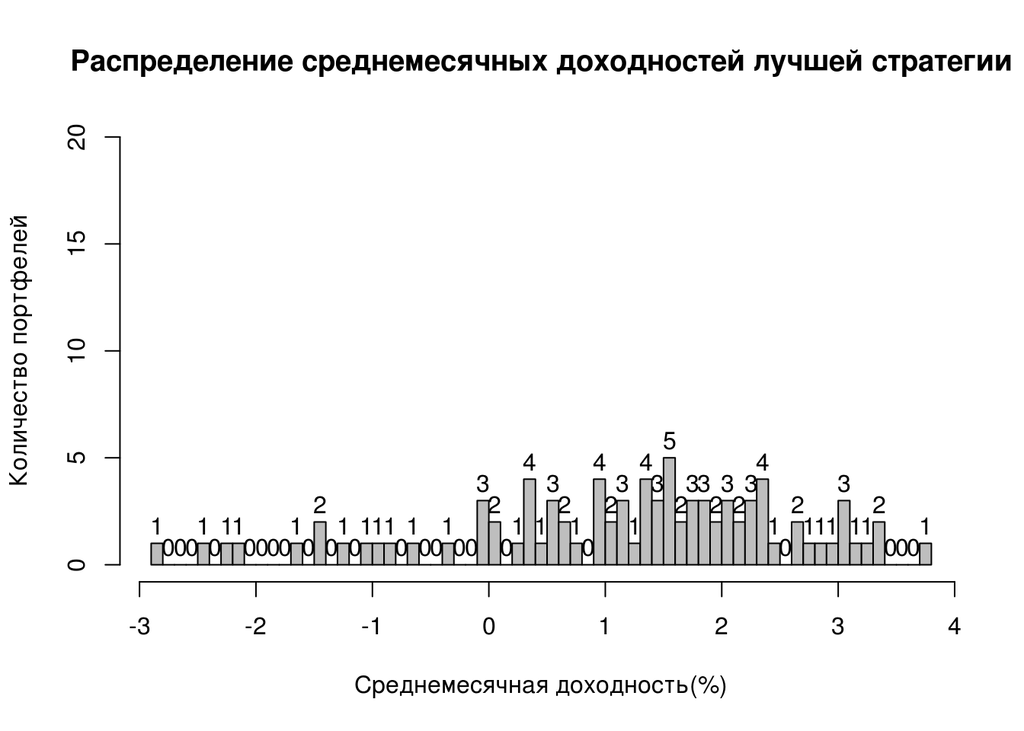

#### **Рисунок 3. (вертикальные пунктирные линии - начало нового года)**

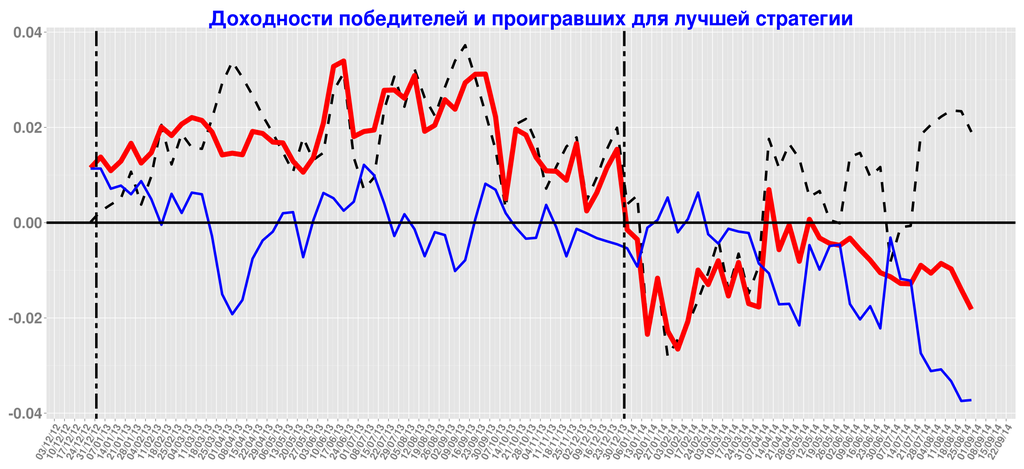

#### **Таблица 4. Доходности победителей и проигравших для лучшей стратегии**

|  | date | Win_portf | Los_portf | Win_Los |
| --- | --- | --- | --- | --- |
| 1 | 2012-12-28 | 0.0115 | 0.0114 | 0.0001 |
| 2 | 2013-01-04 | 0.0138 | 0.0114 | 0.0024 |
| 3 | 2013-01-11 | 0.0109 | 0.0071 | 0.0038 |
| 4 | 2013-01-18 | 0.0129 | 0.0078 | 0.0051 |
| 5 | 2013-01-25 | 0.0167 | 0.006 | 0.0107 |
| 6 | 2013-02-01 | 0.0125 | 0.0087 | 0.0038 |
| 7 | 2013-02-08 | 0.0147 | 0.0049 | 0.0097 |
| 8 | 2013-02-15 | 0.0201 | -0.0004 | 0.0205 |
| 9 | 2013-02-22 | 0.0183 | 0.0061 | 0.0122 |
| 10 | 2013-03-01 | 0.0207 | 0.002 | 0.0187 |

[output cut: 78 more lines]

### **Вхождение в победителей и проигравших для лучшей стратегии**

#### **Рисунок 4.**

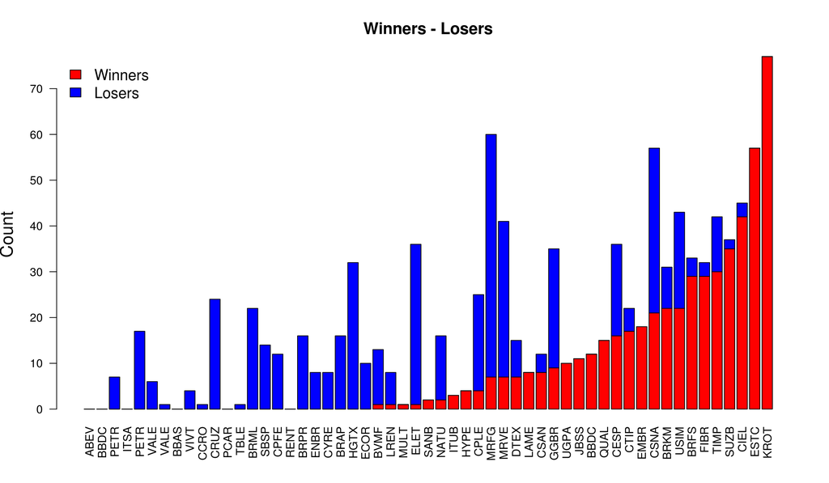

#### **Рисунок 5.**

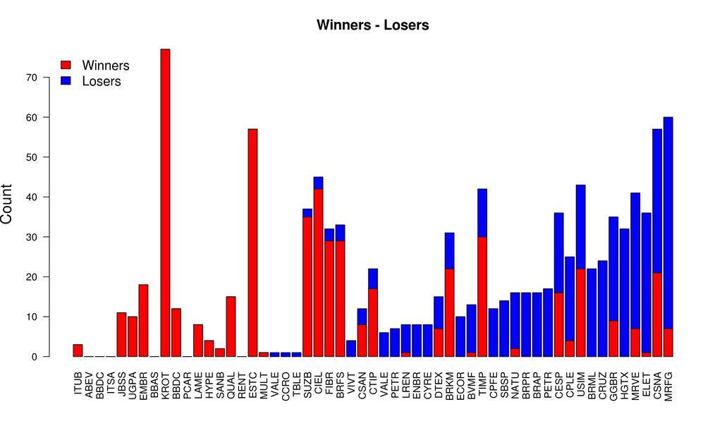

#### **Таблица 5. Вхождение компаний в победители и проигравшие для лучшей по средней доходности стратегии**

|  | Ticket | In_winners | In_losers |
| --- | --- | --- | --- |
| 1 | ITUB4.BS.Equity | 3 | 0 |
| 2 | ABEV3.BS.Equity | 0 | 0 |
| 3 | BBDC4.BS.Equity | 0 | 0 |
| 4 | BRFS3.BS.Equity | 29 | 4 |
| 5 | PETR4.BS.Equity | 0 | 7 |
| 6 | CIEL3.BS.Equity | 42 | 3 |
| 7 | ITSA4.BS.Equity | 0 | 0 |
| 8 | PETR3.BS.Equity | 0 | 17 |
| 9 | VALE5.BS.Equity | 0 | 6 |
| 10 | JBSS3.BS.Equity | 11 | 0 |

[output cut: 45 more lines]

## 2. Моментум стратегии при равных весах. Ранжирование по t-статистике (бенчмарк 6% годовых - только для reality check)

> Лучшая по t-статистике стратегия дает среднемесячную доходность **0.79** **%** и имеет параметры: период отбора – **9** месяцев, период ожидания – **1** недель, период инвестирования – **12** месяцев, процентиль – **0.3**

> Bootstrap p-value равен **0.378**

> Всего портфелей у лучшей по t-статистике стратегии – **88** Количество отрицательных доходностей у лучшей по t-статистике стратегии – **6** ( **6.82%** )

#### **Рисунок 6.**

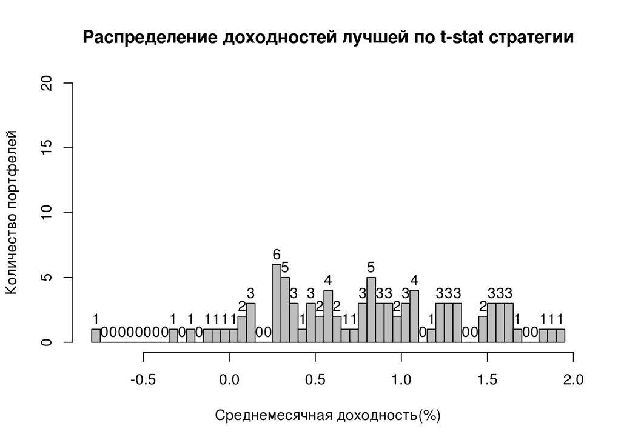

#### **Рисунок 7. (вертикальные пунктирные линии - начало нового года)**

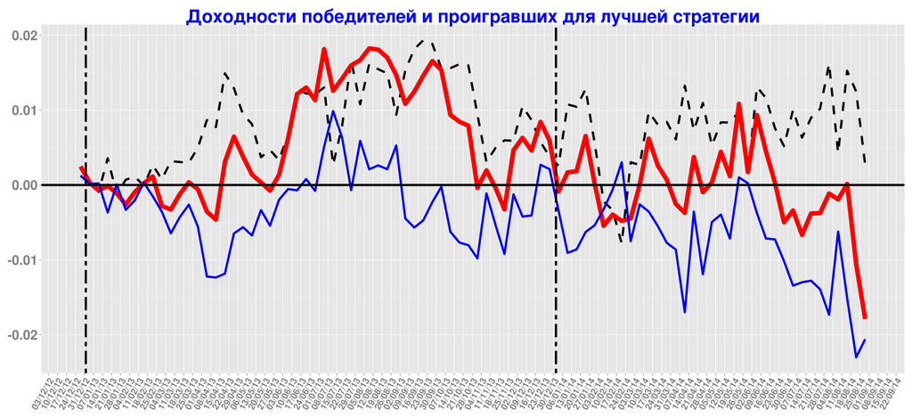

#### **Таблица 6. Доходности победителей и проигравших для лучшей стратегии**

|  | date | Win_portf | Los_portf | Win_Los |
| --- | --- | --- | --- | --- |
| 1 | 2012-12-28 | 0.0025 | 0.0012 | 0.0013 |
| 2 | 2013-01-04 | 0.0003 | 0.0002 | 0.0001 |
| 3 | 2013-01-11 | -0.0007 | 0.0002 | -0.0009 |
| 4 | 2013-01-18 | -0.0001 | -0.0037 | 0.0036 |
| 5 | 2013-01-25 | -0.0011 | 0.0001 | -0.0012 |
| 6 | 2013-02-01 | -0.0026 | -0.0033 | 0.0007 |
| 7 | 2013-02-08 | -0.001 | -0.0021 | 0.0011 |
| 8 | 2013-02-15 | 0.0002 | 0.0003 | -0.0001 |
| 9 | 2013-02-22 | 0.0011 | -0.0015 | 0.0027 |
| 10 | 2013-03-01 | -0.0028 | -0.0036 | 0.0008 |

[output cut: 78 more lines]

### **Вхождение в победителей и проигравших для лучшей стратегии**

#### **Рисунок 8.**

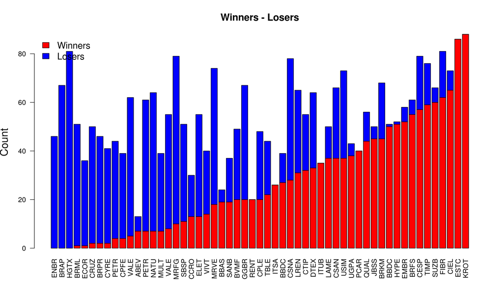

#### **Рисунок 9.**

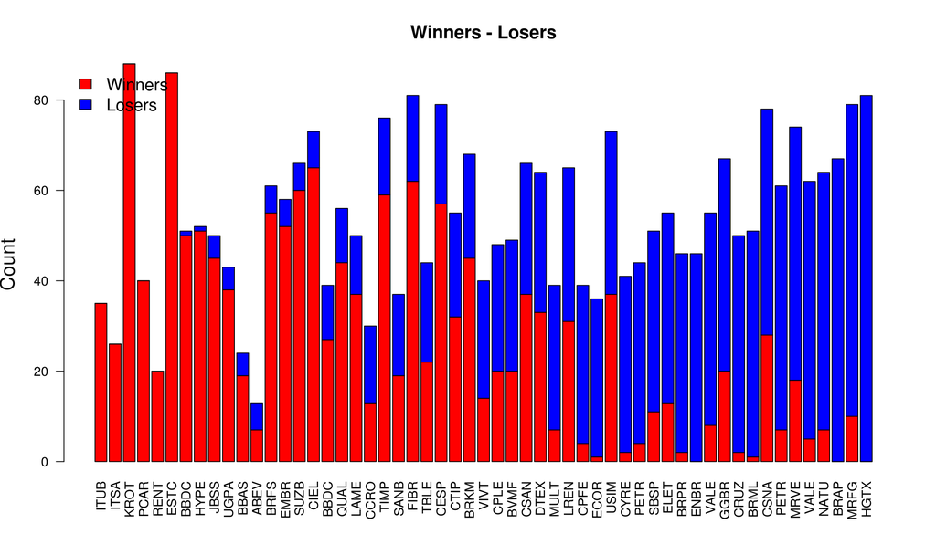

#### **Таблица 7. Вхождение компаний в победители и проигравшие для лучшей по t-статистике стратегии**

|  | Ticket | In_winners | In_losers |
| --- | --- | --- | --- |
| 1 | ITUB4.BS.Equity | 35 | 0 |
| 2 | ABEV3.BS.Equity | 7 | 6 |
| 3 | BBDC4.BS.Equity | 27 | 12 |
| 4 | BRFS3.BS.Equity | 55 | 6 |
| 5 | PETR4.BS.Equity | 4 | 40 |
| 6 | CIEL3.BS.Equity | 65 | 8 |
| 7 | ITSA4.BS.Equity | 26 | 0 |
| 8 | PETR3.BS.Equity | 7 | 54 |
| 9 | VALE5.BS.Equity | 5 | 57 |
| 10 | JBSS3.BS.Equity | 45 | 5 |

[output cut: 45 more lines]